# Übung 3.2.7

ses

4/9/2021

# 1 Hintergrund

Hier besprechen wir [diese Aufgabe](https://openintro-ims.netlify.app/intro-linear-models.html#least-squares-regression-exercises).

# 2 Aufgabe “The Coast Starlight, regression”

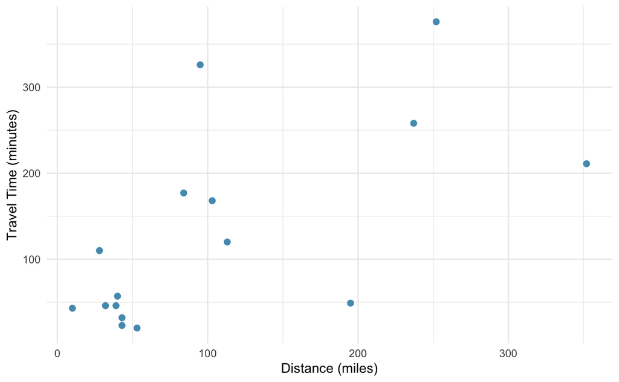

## 2.1 a)

> Write the equation of the regression line for predicting travel time.

$y = \beta_0 + \beta_1*x$

### 2.1.1 beta1

Wir berechnen zuerst beta1:

$\beta_1 = (s_y / s_x) * r$

```r
beta1 <- (113/99) * .64
beta1
```

```
## [1] 0.7305051
```

$\beta_1$ beträgt 0.73.

### 2.1.2 beta0

Danach berechnen wir beta0:

$\bar{x}, \bar{y}$ liegt auf der Regressionsgeraden.

y = beta0 + beta1x

Also:

129 = beta0 + 0.73 * 108

```r
beta0 = 129 - 0.73 * 108
beta0
```

```
## [1] 50.16
```

$\beta_0$ liegt bei 50.16.

### 2.1.3 Antwort

Die Regressionsformel sieht also so aus.

**y = 50 + 0.73x**

## 2.2 b)

> Interpret the slope and the intercept in this context.

## 2.3 c)

> Calculate R<sup>2</sup> of the regression line for predicting travel time from distance traveled for the Coast Starlight, and interpret R<sup>2</sup> in the context of the application.

```r
r <- 0.636
R2 <- r^2
R2
```

```
## [1] 0.404496
```

Das ist der Anteil der vom Modell erklärten Varianz.

## 2.4 d)

> The distance between Santa Barbara and Los Angeles is 103 miles. Use the model to estimate the time it takes for the Starlight to travel between these two cities.

**y = 50 + 0.73x**

```r
y1_erwartet <- 50 + 0.73 * 103
y1_erwartet
```

```
## [1] 125.19
```

erwartet: y-dach: $\hat{y}$

## 2.5 e)

> It actually takes the Coast Starlight about 168 mins to travel from Santa Barbara to Los Angeles. Calculate the residual and explain the meaning of this residual value.